# FIFA Notebook by Pranav and Ajay (8672, 8708)

This is an [R](http://rmarkdown.rstudio.com) Notebook. When you execute code within the notebook, the results appear beneath the code.

### Load the Data

We will load the dataset with all the players and also load libraries to do all the analysis.

```r
library(readr)
FullData <- read_csv("/home/oem/Code/mlprojects/FIFA/more/complete.csv", show_col_types = FALSE)
complement <- read_csv("/home/oem/Code/mlprojects/FIFA/demo/CompleteDataset.csv", show_col_types = FALSE)
df <- read.csv("/home/oem/Code/mlprojects/FIFA/fifa21_male2.csv", stringsAsFactors = FALSE)
```

### Summary of the Data

```r
library(data.table)
setDT(FullData)
setDT(complement)
names(FullData)
```

```
  [1] "ID"                                 "name"                               "full_name"                          "club"
  [5] "club_logo"                          "special"                            "age"                                "league"
  [9] "birth_date"                         "height_cm"                          "weight_kg"                          "body_type"
 [13] "real_face"                          "flag"                               "nationality"                        "photo"
 [17] "eur_value"                          "eur_wage"                           "eur_release_clause"                 "overall"
 [21] "potential"                          "pac"                                "sho"                                "pas"
 [25] "dri"                                "def"                                "phy"                                "international_reputation"
 [29] "skill_moves"                        "weak_foot"                          "work_rate_att"                      "work_rate_def"
 [33] "preferred_foot"                     "crossing"                           "finishing"                          "heading_accuracy"
 [37] "short_passing"                      "volleys"                            "dribbling"                          "curve"
 [41] "free_kick_accuracy"                 "long_passing"                       "ball_control"                       "acceleration"
 [45] "sprint_speed"                       "agility"                            "reactions"                          "balance"
 [49] "shot_power"                         "jumping"                            "stamina"                            "strength"
 [53] "long_shots"                         "aggression"                         "interceptions"                      "positioning"
 [57] "vision"                             "penalties"                          "composure"                          "marking"
```

[output cut: 32 more lines]

We have a fairly complete dataset. The first 94 columns are mostly quantitative variables, Some are personal data of the players such as their age, height, etc. and others are statistical data. From column 95 are Boolean qualities of each player.

#### Dimensions of FullData

```r
dim(FullData)
```

```
[1] 17994   185
```

```r
library(knitr)
head(FullData)
```

| ID | name | full_name | club | club_logo | special | age | league | birth_date | height_cm | weight_kg | body_type | real_face | flag | nationality | photo | eur_value | eur_wage | eur_release_clause | overall | potential | pac | sho | pas | dri | def | phy | international_reputation | skill_moves | weak_foot | … |
| --- | --- | --- | --- | --- | --- | --- | --- | --- | --- | --- | --- | --- | --- | --- | --- | --- | --- | --- | --- | --- | --- | --- | --- | --- | --- | --- | --- | --- | --- | --- |
| 20801 | Cristiano Ronaldo | C. Ronaldo dos Santos Aveiro | Real Madrid CF | https://cdn.sofifa.org/18/teams/243.png | 2228 | 32 | Spanish Primera División | 1985-02-05 | 185 | 80 | C. Ronaldo | TRUE | https://cdn.sofifa.org/flags/38@3x.png | Portugal | https://cdn.sofifa.org/18/players/20801.png | 9.55e+07 | 565000 | 195800000 | 94 | 94 | 90 | 93 | 82 | 90 | 33 | 80 | 5 | 5 | 4 | … |
| 158023 | L. Messi | Lionel Messi | FC Barcelona | https://cdn.sofifa.org/18/teams/241.png | 2158 | 30 | Spanish Primera División | 1987-06-24 | 170 | 72 | Messi | TRUE | https://cdn.sofifa.org/flags/52@3x.png | Argentina | https://cdn.sofifa.org/18/players/158023.png | 1.05e+08 | 565000 | 215300000 | 93 | 93 | 89 | 90 | 86 | 96 | 26 | 61 | 5 | 4 | 4 | … |
| 190871 | Neymar | Neymar da Silva Santos Jr. | Paris Saint-Germain | https://cdn.sofifa.org/18/teams/73.png | 2100 | 25 | French Ligue 1 | 1992-02-05 | 175 | 68 | Neymar | TRUE | https://cdn.sofifa.org/flags/54@3x.png | Brazil | https://cdn.sofifa.org/18/players/190871.png | 1.23e+08 | 280000 | 236800000 | 92 | 94 | 92 | 84 | 79 | 95 | 30 | 60 | 5 | 5 | 5 | … |
| 176580 | L. Suárez | Luis Suárez | FC Barcelona | https://cdn.sofifa.org/18/teams/241.png | 2291 | 30 | Spanish Primera División | 1987-01-24 | 182 | 86 | Normal | TRUE | https://cdn.sofifa.org/flags/60@3x.png | Uruguay | https://cdn.sofifa.org/18/players/176580.png | 9.70e+07 | 510000 | 198900000 | 92 | 92 | 82 | 90 | 79 | 87 | 42 | 81 | 5 | 4 | 4 | … |
| 167495 | M. Neuer | Manuel Neuer | FC Bayern Munich | https://cdn.sofifa.org/18/teams/21.png | 1493 | 31 | German Bundesliga | 1986-03-27 | 193 | 92 | Normal | TRUE | https://cdn.sofifa.org/flags/21@3x.png | Germany | https://cdn.sofifa.org/18/players/167495.png | 6.10e+07 | 230000 | 100700000 | 92 | 92 | 91 | 90 | 95 | 89 | 60 | 91 | 5 | 1 | 4 | … |
| 188545 | R. Lewandowski | Robert Lewandowski | FC Bayern Munich | https://cdn.sofifa.org/18/teams/21.png | 2146 | 28 | German Bundesliga | 1988-08-21 | 185 | 79 | Normal | TRUE | https://cdn.sofifa.org/flags/37@3x.png | Poland | https://cdn.sofifa.org/18/players/188545.png | 9.20e+07 | 355000 | 151800000 | 91 | 91 | 81 | 88 | 75 | 86 | 38 | 82 | 4 | 3 | 4 | … |

### Ages of football players

We can see that most of the players are under their 30s. the minimum age is 16, the maximum is 47.

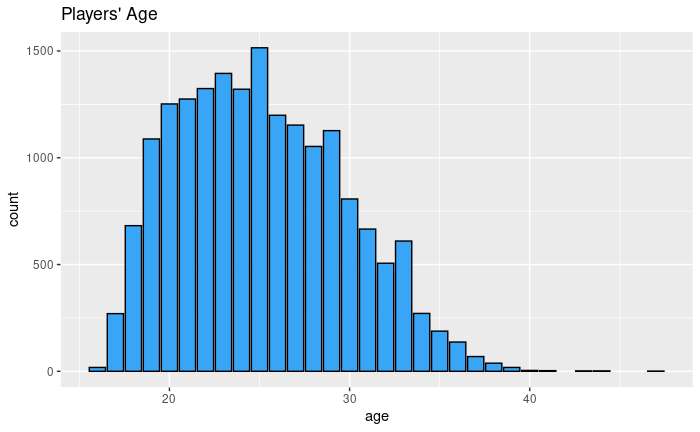

```r
library(ggplot2)
ggplot(FullData, aes(age, fill = age)) +
geom_bar(position = "stack", color="black", fill= "#39a5f7") +
labs(title="Players' Age")
```

### Players’ Overall Rating

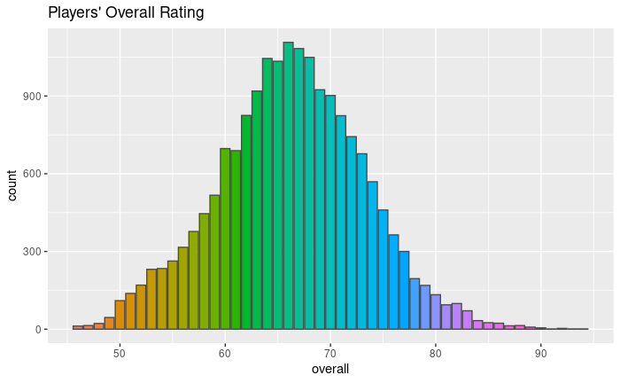

```r
library(dplyr)
FullData %>%
  ggplot(aes(x = overall, fill = factor(overall))) +
  geom_bar(color = "grey30") + guides(fill = FALSE)+
  labs(title="Players' Overall Rating")
```

Interestingly, the overall follow a fairly symmetrical bell-shaped distribution. The minimum rating is 46, the maximum is 94, the mean is 66.2530288.

### Age vs Rating

```r
agerating <- FullData[age<41,.("overall"=mean(overall)),by=age][order(-age)]
agerating
```

| age | overall |
| --- | --- |
| 40 | 73.75000 |
| 39 | 67.88889 |
| 38 | 68.78947 |
| 37 | 68.36232 |
| 36 | 69.00730 |
| 35 | 68.94681 |
| 34 | 68.88192 |
| 33 | 69.68689 |
| 32 | 69.45257 |
| 31 | 69.71471 |

[output cut: 15 more lines]

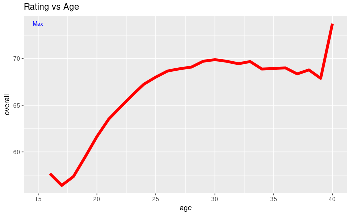

```r
ggplot(data = agerating,aes(x=age,y=overall))+
  geom_line(color="red",size=2)+labs(title="Rating vs Age")+
  annotate("text", x = 15, y = max(agerating$overall),color="blue", label = "Max", parse = TRUE, size = 3)
```

In the graph of the Rating of the players we observed that the players are improving with the step of the years. The best players are 30 years old and after that they start to decline. It is seen that in the 40 there is a peak in the graph again, this may be due to the veterans included in the games.

### Best Players

Based on the rating we will see which are the best 10 players.

```r
library(data.table)
FullData %>%
  select(name, age,overall,club,eur_value, nationality) %>%
  as.data.table(class = "nowrap hover row-border", escape = TRUE, options = list(dom = 't',scrollX = TRUE, autoWidth = FALSE))
```

| name | age | overall | club | eur_value | nationality |
| --- | --- | --- | --- | --- | --- |
| Cristiano Ronaldo | 32 | 94 | Real Madrid CF | 9.55e+07 | Portugal |
| L. Messi | 30 | 93 | FC Barcelona | 1.05e+08 | Argentina |
| Neymar | 25 | 92 | Paris Saint-Germain | 1.23e+08 | Brazil |
| L. Suárez | 30 | 92 | FC Barcelona | 9.70e+07 | Uruguay |
| M. Neuer | 31 | 92 | FC Bayern Munich | 6.10e+07 | Germany |
| R. Lewandowski | 28 | 91 | FC Bayern Munich | 9.20e+07 | Poland |
| De Gea | 26 | 90 | Manchester United | 6.45e+07 | Spain |
| E. Hazard | 26 | 90 | Chelsea | 9.05e+07 | Belgium |
| T. Kroos | 27 | 90 | Real Madrid CF | 7.90e+07 | Germany |
| G. Higuaín | 29 | 90 | Juventus | 7.70e+07 | Argentina |

[output cut: 990 more lines]

### Physical Attributes of the Players

#### Height in cm

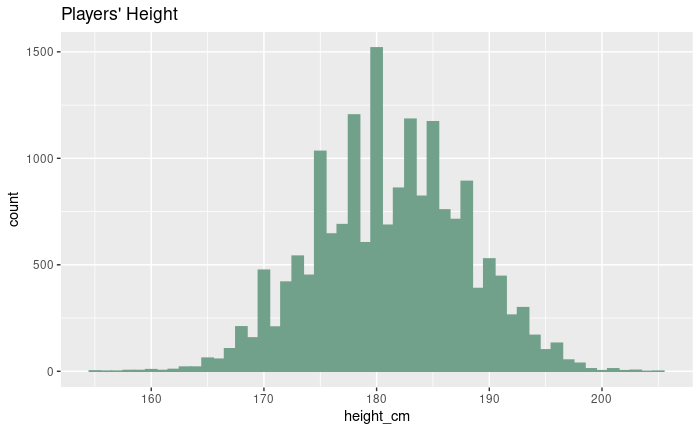

```r
FullData %>%
  ggplot(aes(x = height_cm)) +
  geom_histogram(binwidth= 1,color = "#72a18b", fill="#72a18b") +
  labs(title="Players' Height")
```

The height_cm follows a fairly symmetrical bell-shaped distribution. The minimum height is 155, the maxima is 205, the mean is 181.2719795.

#### Weight in kg

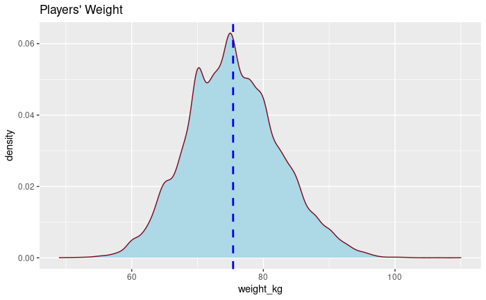

```r
FullData %>%
  ggplot(aes(x = weight_kg)) +
  geom_density(color = "#78081b", fill="lightblue") +
  geom_vline(aes(xintercept=mean(weight_kg)),
            color="blue", linetype="dashed", size=1)+
  labs(title="Players' Weight")
```

The weight_kg follows a fairly symmetrical bell-shaped distribution. The minimum height is 49, the maxima is 110, the mean is 75.4008558

#### Height and Weight

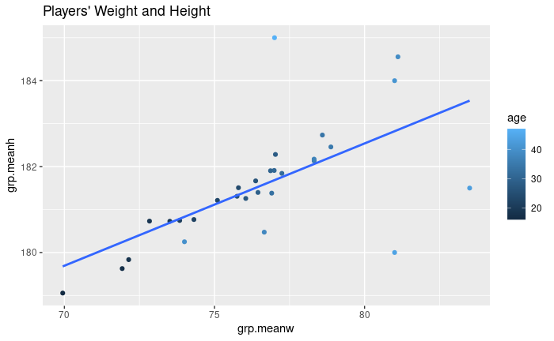

```r
library(plyr)
mw <- ddply(FullData, "age", summarise, grp.meanw=mean(weight_kg), grp.meanh=mean(height_cm))
ggplot(mw, aes(x=grp.meanw, y=grp.meanh, color = age)) +
  geom_point(aes()) +
  geom_smooth(method=lm, se=FALSE, fullrange=TRUE)+
  labs(title="Players' Weight and Height")
```

We plot the mean height and weight for all ages of players. We also plot a regression line and find the optimum values.

### Wage offered to Players w.r.t Ages

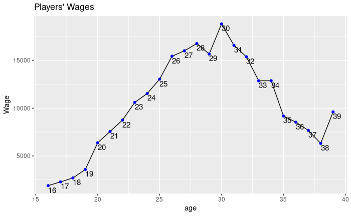

```r
d <- FullData[age<40,.("Wage"=mean(eur_wage)),by=age][order(-age)]
ggplot(d, aes(x=age, y=Wage,label = age)) +
  geom_line()+
  geom_point(color= "blue") +
  geom_text(size =4,hjust=0, vjust=1.3)+
  labs(title="Players' Wages")
```

From the graph we infer that the wages offered to the players increases with their age and experience. As the player reaches his prime playing years, his wages are the highest. But after that we can see the wages dropping. At the end we can see a peak in the wages. This is because of the veterans playing the game.

### Nationalities of Players

```r
Nationalitys <- FullData[FullData$nationality!="",.N,by=.(nationality,`flag`)][order(-N)]
Nationalitys = Nationalitys[,c(1,3)]
head(Nationalitys[order(Nationalitys$N, decreasing = TRUE),],10)
```

| nationality | N |
| --- | --- |
| England | 1631 |
| Germany | 1147 |
| Spain | 1020 |
| France | 966 |
| Argentina | 962 |
| Brazil | 806 |
| Italy | 800 |
| Colombia | 593 |
| Japan | 471 |
| Netherlands | 430 |

The countries with the largest number of players are Europeans followed by South Americans.

### Best Teams in the Game

All players who are affiliated with the teams are taken into account. That means that even the substitutes are taken into account to make the averages.

#### Best Clubs

```r
TeamDF<-arrange(FullData[, list(Avg=mean(overall)), by= "club" ], desc(Avg) )
head(TeamDF, 10)
```

| club | Avg |
| --- | --- |
| FC Barcelona | 82.75000 |
| Juventus | 81.69231 |
| Real Madrid CF | 79.85714 |
| FC Bayern Munich | 79.15385 |
| Paris Saint-Germain | 77.96429 |
| Manchester United | 77.78788 |
| Napoli | 77.70370 |
| Roma | 77.37037 |
| Sevilla FC | 77.00000 |
| Inter | 76.70833 |

The best is Barelona. And the data proves it.

## Clustering

### Number of Clusters

We will group all the players in groups according to their statistical characteristics. But before making the groups we need to know how many groups we want to make. For that we will use Ward’s method.

#### Ward’s Method

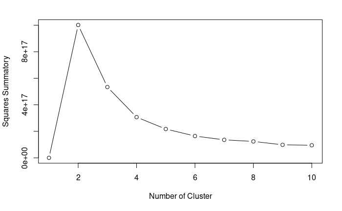

```r
cluster = FullData[,c(7,10,11,17:29,34:94)]
cluster[is.na(cluster)] = 0
wss <- (nrow(cluster[,c()])-1)*sum(apply(cluster[,1:ncol(cluster)],2,var))

for (i in 2:10)
  wss[i] <- sum(kmeans(cluster[,1:ncol(cluster)], centers=i)$withinss)

plot(1:
       10, wss, type="b", xlab="Number of Cluster",  ylab="Squares Summatory")
```

In the graph of Number of Clusters you can see a big change between 2 and 4. After 4 the change is minimal with the following amount, although the difference between 4 and 10 is already considerable.

### K Means Clustering

We will make the clusters and then analyze them independently to see what the groupings are based on.

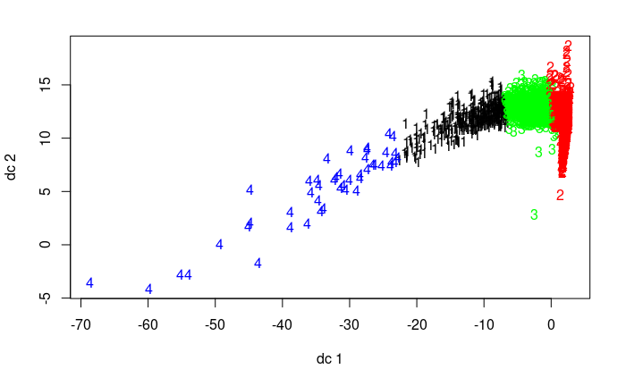

```r
library(fpc)
km<-kmeans(cluster[,1:ncol(cluster)],4)
cluster$grupo<-km$cluster
FullData$grupo <-km$cluster
g1<- FullData[FullData$grupo==1,]
g2<- FullData[FullData$grupo==2,]
g3<- FullData[FullData$grupo==3,]
g4<- FullData[FullData$grupo==4,]

plotcluster(cluster[,1:(ncol(cluster)-1)],km$cluster)
```

The Group 2 has 15752 players, Group 4 has 46 players, Group 3 has 1859 players and Group 1 has 337 players. These values total 17994.

### Player’s Overall Ratings according to the groups

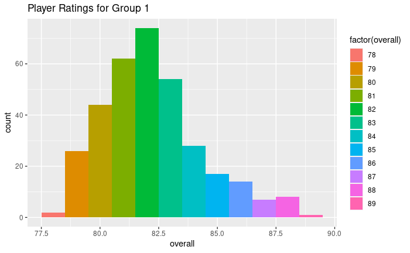

```r
g1 %>%
  ggplot(aes(x = overall, fill = factor(overall))) +
  geom_histogram(binwidth=1)+
  labs(title="Player Ratings for Group 1")
```

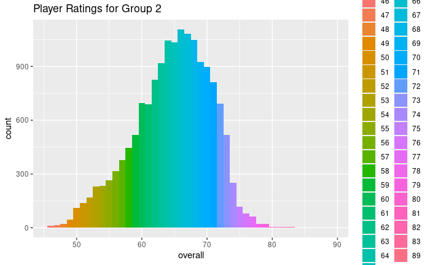

```r
g2 %>%
  ggplot(aes(x = overall, fill = factor(overall))) +
  geom_histogram(binwidth = 1) +
  labs(title="Player Ratings for Group 2")
```

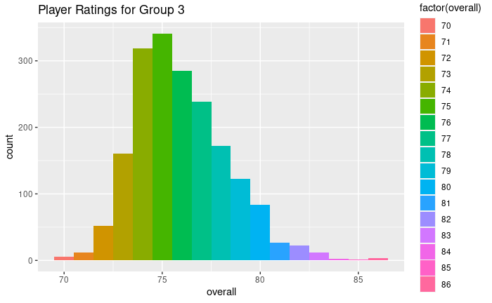

```r
g3 %>%
  ggplot(aes(x = overall, fill = factor(overall))) +
  geom_histogram(binwidth=1)+
  labs(title="Player Ratings for Group 3")
```

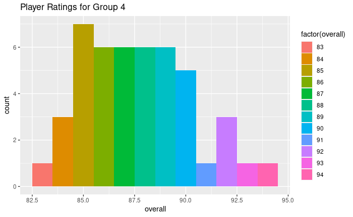

```r
g4 %>%
  ggplot(aes(x = overall, fill = factor(overall))) +
  geom_histogram(binwidth=1)+
  labs(title="Player Ratings for Group 4")
```

### Density of EUR_Value for Players in Groups

We find the distribution of the EUR_Value in the density graph.

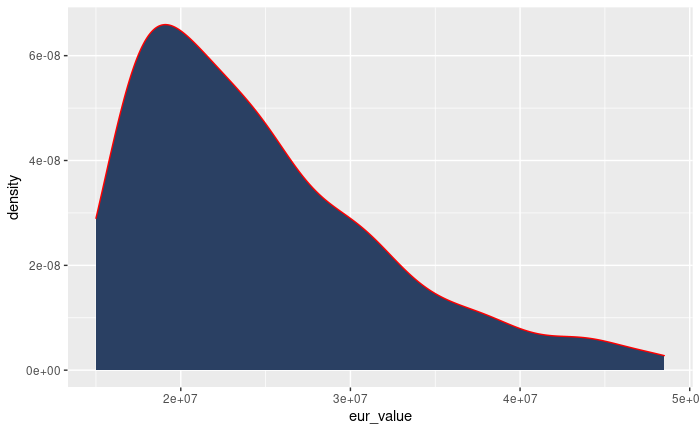

```r
ggplot(g1, aes(eur_value, fill = eur_value)) +
geom_density(position = "stack", fill = "#2a4063", color = "red")
```

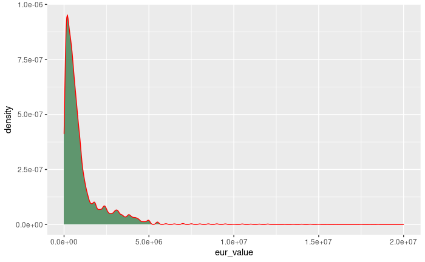

```r
ggplot(g2, aes(eur_value, fill = eur_value)) +
geom_density(position = "stack", fill = "#5f966e", color = "red")
```

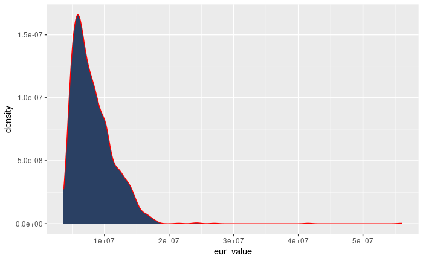

```r
ggplot(g3, aes(eur_value, fill = eur_value)) +
geom_density(position = "stack", fill = "#2a4063", color = "red")
```

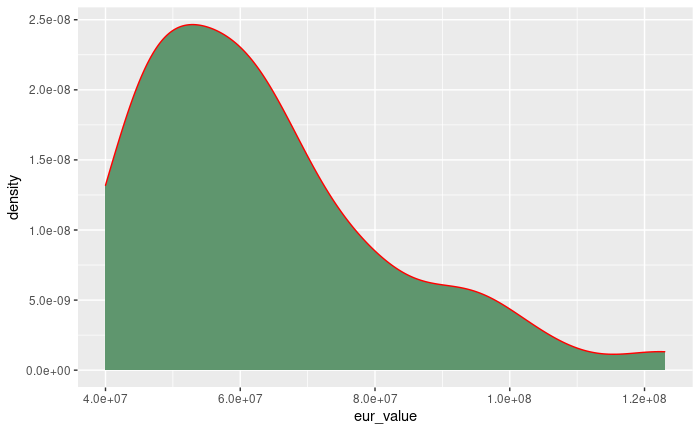

```r
ggplot(g4, aes(eur_value, fill = eur_value)) +
geom_density(position = "stack", fill = "#5f966e", color = "red")
```

### Comparison of Group1 and Group2

```r
summary(g1$eur_value)
```

```
    Min.  1st Qu.   Median     Mean  3rd Qu.     Max.
15000000 18500000 23000000 24686944 29000000 48500000
```

```r
summary(g2$eur_value)
```

```
    Min.  1st Qu.   Median     Mean  3rd Qu.     Max.
       0   270000   575000  1023342  1100000 20000000
```

### Comparison of Group3 and Group4

```r
summary(g3$eur_value)
```

```
    Min.  1st Qu.   Median     Mean  3rd Qu.     Max.
 3700000  6000000  7500000  8231469 10000000 56000000
```

```r
summary(g4$eur_value)
```

```
     Min.   1st Qu.    Median      Mean   3rd Qu.      Max.
 40000000  48500000  59000000  63336957  70250000 123000000
```

With the previous explorations, it can be said that nationality does not govern in which group a player belongs. But you can see that the rating of a player can place you inside or outside a group. In the analysis the rating vs age (years) was analyzed, and it is noted that they are quite proportional. As well as the rating, the eur_value of the players is also crucial to be in a specific group.

In the following groups

- Group 2
- Group 3
- Group 1
- Group 4

They are sorted in descending order according to their number of players. You can see that Group 4 contains 46 players and Group 1 has 337 players. This only represent 2.12848727 % of the players. Leaving the rest as players outside of world class players.

## Machine Learning

### Predicting Position

We are talking about football players, and they all have certain position.They are ranked from GK to RW. They also have statistics about all their specs. Lets try to predict if the players play defense or attack.

```r
library(caret)
library(plyr)
specs = FullData[,c(22:30,36:67)]
specs = data.frame(specs)

## Specs normalization
specsNorm = preProcess(specs,method = "scale")
specs = predict(specsNorm, specs)
## Adding ID and Overall to Specs
id_overall = FullData[,c(1,20)]
specs = cbind(specs,id_overall)

##Getting preferred_positions and ID
positions = complement[,c(53,64)]
positions = data.frame(positions)

## Cleaning Preferred Positions
prefered_positions = positions[,'Preferred.Positions']
split = strsplit(prefered_positions, split=" ")
positionVector = 0
length = length(split)
for (position in 1:length) {
    positionVector[position] <- unlist(split[[position]][1])
  }
positions[,'Preferred.Positions'] = positionVector

#Joining data
selected_data = join(specs, positions, by = NULL, type = "full", match = "first")
selected_data = selected_data[complete.cases(selected_data),]

#Attack or Defense
position = selected_data[,'Preferred.Positions']
attack = c('ST','LW','RW','RM','CM','LM','CAM','CF')
defense = c('CDM','CB','LB','RB','RWB','LWB','GK')
#Replacing
position <- lapply(position, function(x) replace(x,x %in% attack, 1))
position <- lapply(position, function(x) replace(x,x %in% defense, 0))

positionVector = 0
for (i in 1:length(position)){
    positionVector[i] = position[[i]]
}

positionVector = as.numeric(positionVector)

#joining
selected_data = cbind(selected_data,positionVector)

selected_data <- subset( selected_data, select = -ID )
selected_data[,'Preferred.Positions'] = as.factor(selected_data[,'Preferred.Positions'])

head(selected_data)
```

|  | pac | sho | pas | dri | def | phy | international_reputation | skill_moves | weak_foot | heading_accuracy | short_passing | volleys | dribbling | curve | free_kick_accuracy | long_passing | ball_control | acceleration | sprint_speed | agility | reactions | balance | shot_power | jumping | stamina | strength | long_shots | aggression | interceptions | … |
| --- | --- | --- | --- | --- | --- | --- | --- | --- | --- | --- | --- | --- | --- | --- | --- | --- | --- | --- | --- | --- | --- | --- | --- | --- | --- | --- | --- | --- | --- | --- |
| 1 | 8.228462 | 6.722675 | 7.834288 | 8.672714 | 1.927549 | 8.283646 | 12.397815 | 6.702125 | 6.050458 | 5.058780 | 5.582610 | 4.9632127 | 4.801191 | 4.3898600 | 4.3253411 | 4.970841 | 5.552139 | 5.980952 | 6.231380 | 6.031828 | 10.503925 | 4.470178 | 5.408761 | 7.997463 | 5.794987 | 6.335037 | 4.7748291 | 3.609157 | 1.402037 | … |
| 2 | 8.137034 | 6.505814 | 8.216448 | 9.250895 | 1.518675 | 6.316280 | 12.397815 | 5.361700 | 6.050458 | 4.081516 | 5.918911 | 4.7940122 | 5.117753 | 4.8234265 | 5.1221144 | 5.616404 | 5.671540 | 6.182557 | 5.957473 | 6.099601 | 10.394509 | 6.740745 | 4.890901 | 5.724500 | 4.598196 | 4.672090 | 4.5672278 | 2.749834 | 1.063614 | … |
| 3 | 8.411316 | 6.072093 | 7.547668 | 9.154531 | 1.752317 | 6.212735 | 12.397815 | 6.702125 | 7.563073 | 3.564140 | 5.448089 | 4.6812120 | 5.064993 | 4.3898600 | 4.7806402 | 4.841728 | 5.671540 | 6.316960 | 6.162904 | 6.506241 | 9.628598 | 5.818327 | 4.603201 | 5.135213 | 4.913141 | 4.196962 | 3.9963243 | 3.208139 | 1.740459 | … |
| 4 | 7.497043 | 6.505814 | 7.547668 | 8.383623 | 2.453244 | 8.387192 | 12.397815 | 5.361700 | 6.050458 | 4.426433 | 5.582610 | 4.9632127 | 4.537389 | 4.6608390 | 4.7806402 | 4.131608 | 5.432738 | 5.913750 | 5.272706 | 5.828508 | 10.175677 | 4.257313 | 5.005981 | 5.808683 | 5.606020 | 6.335037 | 4.4634272 | 4.468480 | 1.982190 | … |
| 5 | 8.319889 | 6.505814 | 9.076309 | 8.576350 | 3.504634 | 9.422648 | 12.397815 | 1.340425 | 6.050458 | 1.437153 | 3.699320 | 0.6204016 | 1.582810 | 0.7587412 | 0.6260362 | 3.808826 | 2.865620 | 3.897699 | 4.177079 | 3.524214 | 9.300350 | 2.483432 | 1.438500 | 6.566338 | 2.771516 | 6.572601 | 0.8304051 | 1.661358 | 1.450383 | … |
| 6 | 7.405616 | 6.361241 | 7.165507 | 8.287260 | 2.219602 | 8.490737 | 9.918252 | 4.021275 | 6.050458 | 4.886322 | 5.582610 | 4.9068125 | 4.484629 | 4.1730768 | 4.7806402 | 4.196164 | 5.313337 | 5.308935 | 5.683567 | 5.286321 | 9.956845 | 5.676417 | 5.063521 | 7.071441 | 4.976130 | 6.651789 | 4.3077262 | 4.583056 | 1.885497 | … |

### Splitting the Data 70/30

Now that we have our data ready for process, we are going to divede the in 2 groups. One would be for training the algorithm and the other to test it.

```r
percent <- 70/100

set.seed(3)

trainRowsNumber<-sample(1:nrow(selected_data),percent*nrow(selected_data))
train<-selected_data[trainRowsNumber,]
test<-selected_data[-trainRowsNumber,]

ataque = selected_data[selected_data[,'positionVector'] ==1,-positionVector]
ataque$Preferred.Positions = factor(ataque$Preferred.Positions)
defensa = selected_data[selected_data[,'positionVector'] ==0,-positionVector]
defensa$Preferred.Positions = factor(defensa$Preferred.Positions)

trainRowsNumber<-sample(1:nrow(ataque),percent*nrow(ataque))
trainA<-ataque[trainRowsNumber,]
testA<-ataque[-trainRowsNumber,]

trainRowsNumber<-sample(1:nrow(defensa),percent*nrow(defensa))
trainD<-defensa[trainRowsNumber,]
testD<-defensa[-trainRowsNumber,]

head(train)
```

|  | pac | sho | pas | dri | def | phy | international_reputation | skill_moves | weak_foot | heading_accuracy | short_passing | volleys | dribbling | curve | free_kick_accuracy | long_passing | ball_control | acceleration | sprint_speed | agility | reactions | balance | shot_power | jumping | stamina | strength | long_shots | aggression | interceptions | … |
| --- | --- | --- | --- | --- | --- | --- | --- | --- | --- | --- | --- | --- | --- | --- | --- | --- | --- | --- | --- | --- | --- | --- | --- | --- | --- | --- | --- | --- | --- | --- |
| 11124 | 5.759923 | 4.409496 | 5.445785 | 6.456354 | 1.285033 | 6.316280 | 2.479563 | 1.340425 | 3.025229 | 0.6898336 | 1.210686 | 0.394801 | 0.316562 | 0.5961538 | 0.6829486 | 1.032902 | 0.8358058 | 1.142429 | 1.780394 | 2.507614 | 7.221448 | 2.057701 | 1.035720 | 2.862250 | 1.763692 | 5.068029 | 0.4671028 | 1.432205 | 0.6284992 | … |
| 6757 | 7.497043 | 3.686628 | 5.827946 | 5.685446 | 3.621455 | 7.973010 | 2.479563 | 2.680850 | 3.025229 | 3.2767098 | 4.439184 | 2.256006 | 2.849058 | 3.5227272 | 2.3334077 | 4.002495 | 3.7014259 | 5.174531 | 5.888997 | 4.879681 | 6.127289 | 4.470178 | 4.315501 | 7.239808 | 5.165097 | 5.543157 | 2.6988164 | 4.812209 | 2.5139967 | … |
| 6907 | 6.125633 | 1.879457 | 3.534984 | 5.589082 | 4.030329 | 7.351736 | 2.479563 | 2.680850 | 4.537844 | 4.1964880 | 2.555894 | 1.466404 | 3.112860 | 1.1923077 | 1.4228096 | 2.194917 | 3.7611263 | 4.435312 | 4.587939 | 2.710934 | 6.236705 | 3.831581 | 2.186520 | 5.640316 | 4.031295 | 5.939097 | 1.0899066 | 4.124751 | 2.9974576 | … |
| 8247 | 5.028504 | 4.409496 | 6.496727 | 6.263627 | 3.855098 | 7.041099 | 4.959126 | 2.680850 | 4.537844 | 3.8515712 | 4.506444 | 2.481606 | 3.323902 | 3.4143356 | 3.6993049 | 4.260721 | 4.1193288 | 3.897699 | 3.629265 | 4.405268 | 7.002616 | 4.824954 | 4.373041 | 6.145419 | 4.157273 | 5.305593 | 3.4773212 | 4.182039 | 3.0941497 | … |
| 5145 | 7.131333 | 4.843217 | 5.923486 | 6.938171 | 1.985959 | 6.109189 | 2.479563 | 2.680850 | 4.537844 | 3.3916821 | 4.371923 | 3.045608 | 3.851505 | 3.1975524 | 2.4472325 | 3.808826 | 4.1790292 | 4.905724 | 5.615090 | 5.354094 | 7.112032 | 4.966865 | 4.085341 | 5.640316 | 3.338417 | 5.384781 | 2.9064177 | 2.463393 | 1.9338436 | … |
| 8665 | 6.491342 | 4.048062 | 6.592267 | 6.938171 | 1.985959 | 6.523371 | 2.479563 | 4.021275 | 6.050458 | 3.2192237 | 4.910006 | 3.327609 | 3.798745 | 4.4982516 | 3.8700420 | 4.906284 | 4.4775313 | 4.838523 | 4.861846 | 4.201948 | 7.549696 | 5.321641 | 4.085341 | 4.882661 | 3.779339 | 5.859909 | 2.3874145 | 2.291528 | 2.1755740 | … |

### Logistic Regression

```r
model<-glm(positionVector~., data = train)
pred<-predict(model,newdata = test)
pred = round(pred)
cfmLR = confusionMatrix(table(pred,test$positionVector))
cfmLR
```

```
Confusion Matrix and Statistics


pred    0    1
   0 2613    0
   1    0 2694

               Accuracy : 1
                 95% CI : (0.9993, 1)
    No Information Rate : 0.5076
    P-Value [Acc > NIR] : < 2.2e-16

                  Kappa : 1

 Mcnemar's Test P-Value : NA

            Sensitivity : 1.0000
            Specificity : 1.0000
         Pos Pred Value : 1.0000
         Neg Pred Value : 1.0000
             Prevalence : 0.4924
         Detection Rate : 0.4924
   Detection Prevalence : 0.4924
      Balanced Accuracy : 1.0000

       'Positive' Class : 0
```

The model was able to predict 100% of the variance of the data. In the theory means that there is an overfit. The over-adjustment means that if we add another dataset of players we would not predict with such certainty. But knowing that FIFA is the world president of football, datasets will always come in this format. They also cover all the leagues and players in the world. So the overfitting is not taken into account and it can be said that the algorithm can predict with accuracy if a player is attacking or defending.

### SVM

Now that we can predict if a players roll is defending or attacking, we will predict with Support Vector Machine the players position in this two groups (attack and defense)

#### Attack

```r
library(e1071)
model <- svm(Preferred.Positions~. ,data=trainA,kernel = "linear")
prediccion <- predict(model,testA)
cfmSVM<-confusionMatrix(table(prediccion,testA[,'Preferred.Positions']))
cfmSVM
```

```
Confusion Matrix and Statistics


prediccion CAM  CF  CM  LM  LW  RM  RW  ST
       CAM  78  11  41  45  10  32  13  18
       CF    0   0   0   0   0   0   0   0
       CM  116   4 482  66   8  61   3  14
       LM   43   4  28 107  28  80  23  23
       LW    0   0   0   0   0   0   0   0
       RM   56   7  35 132  35 134  35  50
       RW    0   0   0   0   0   0   0   0
       ST   57  27   3  63  35  60  33 592

Overall Statistics

               Accuracy : 0.5175
                 95% CI : (0.4984, 0.5365)
    No Information Rate : 0.2589
    P-Value [Acc > NIR] : < 2.2e-16

                  Kappa : 0.3964

 Mcnemar's Test P-Value : NA

Statistics by Class:

                     Class: CAM Class: CF Class: CM Class: LM Class: LW Class: RM Class: RW Class: ST
Sensitivity             0.22286   0.00000    0.8183   0.25908   0.00000   0.36512   0.00000    0.8494
Specificity             0.92741   1.00000    0.8707   0.89952   1.00000   0.84946   1.00000    0.8607
Pos Pred Value          0.31452       NaN    0.6393   0.31845       NaN   0.27686       NaN    0.6805
Neg Pred Value          0.88871   0.98031    0.9448   0.87012   0.95691   0.89447   0.96025    0.9424
Prevalence              0.13001   0.01969    0.2188   0.15342   0.04309   0.13633   0.03975    0.2589
Detection Rate          0.02897   0.00000    0.1790   0.03975   0.00000   0.04978   0.00000    0.2199
Detection Prevalence    0.09212   0.00000    0.2801   0.12481   0.00000   0.17979   0.00000    0.3232
Balanced Accuracy       0.57513   0.50000    0.8445   0.57930   0.50000   0.60729   0.50000    0.8550
```

The algorithm succeeded in predicting half of the cases. But we can see in the confusion matrix that equivocations always arise in the same line of position.

This means that the algorithm is good at predicting the role of players in attack but fails to predict whether they play on the right, left or center.

#### Defense

```r
modelD <- svm(Preferred.Positions~. ,data=trainD,kernel = "linear")
prediccion <- predict(modelD,testD)
cfmSVM<-confusionMatrix(table(prediccion,testD[,'Preferred.Positions']))
cfmSVM
```

```
Confusion Matrix and Statistics


prediccion  CB CDM  GK  LB LWB  RB RWB
       CB  678  75   0  59   1  94   2
       CDM  47 328   0  22   2  31   2
       GK    0   0 588   0   0   0   0
       LB   44  25   0 208  30 140  12
       LWB   0   0   0   0   0   0   0
       RB   26   9   0  83   9  91   9
       RWB   0   0   0   0   0   0   0

Overall Statistics

               Accuracy : 0.7239
                 95% CI : (0.7063, 0.741)
    No Information Rate : 0.304
    P-Value [Acc > NIR] : < 2.2e-16

                  Kappa : 0.6457

 Mcnemar's Test P-Value : NA

Statistics by Class:

                     Class: CB Class: CDM Class: GK Class: LB Class: LWB Class: RB Class: RWB
Sensitivity             0.8528     0.7506    1.0000   0.55914    0.00000   0.25562    0.00000
Specificity             0.8731     0.9522    1.0000   0.88810    1.00000   0.93980    1.00000
Pos Pred Value          0.7459     0.7593    1.0000   0.45316        NaN   0.40088        NaN
Neg Pred Value          0.9314     0.9501    1.0000   0.92393    0.98394   0.88903    0.99044
Prevalence              0.3040     0.1671    0.2249   0.14226    0.01606   0.13614    0.00956
Detection Rate          0.2593     0.1254    0.2249   0.07954    0.00000   0.03480    0.00000
Detection Prevalence    0.3476     0.1652    0.2249   0.17553    0.00000   0.08681    0.00000
Balanced Accuracy       0.8630     0.8514    1.0000   0.72362    0.50000   0.59771    0.50000
```

The algorithm predicted 70% of cases. But we can see in the confusion matrix that equivocations always arise in the same line of position.

Explanation: The algorithm is good at predicting the role in the defense of players but fails to predict whether they play on the right, left or center.

#### **Observation: The difference of 20% of certainty compared to the attackers is due to the ‘GK’ since they are the easiest position to predict.**

## Additional Analytics

### Data Manipulation

```r
options(repr.matrix.max.cols=150)
library(dplyr)
library(stringr)
library(tidyr)
df2 <- suppressWarnings(df %>%
    # Remove Retired Players
    separate(Contract, c("Contract1", "Contract2"), sep = " ~ ") %>%
    mutate_at(vars(Contract1:Contract2), funs(as.numeric)) %>%
    filter(Contract1 >= 2020 | Contract2 > 2020 ) %>%
    # Height & Weight Transformation (KG, CM)
    mutate(Height = round(
    as.numeric(str_sub(str_remove_all(Height, '"'), start = 1, end = 1))*30.48 + as.numeric(str_sub(str_remove_all(Height, '"'), start = 3, end = 5))* 2.54
    ),
           Weight = round(as.numeric(str_sub(Weight, start = 1, end = 3)) / 2.204623)) %>%
    # Create Position Class
    mutate(Class = case_when(

        BP %in% c("CB", "RB", "LB", "LWB", "RWB", "LCB", "RCB") ~ "Defence",
        BP == "GK" ~ "Goal Keeper",
        BP %in% c("CM", "CDM","CAM","LM","RM", "LAM", "RAM", "LCM", "RCM", "LDM", "RDM") ~ "Midfielder",
        TRUE ~ "Forward"

    )) %>%
    # Market Values & Wage
    mutate(
        Values = as.numeric(str_replace_all(str_remove_all(str_remove_all(Value,"€"), "M"), "K", "000")),
        Values = if_else(Values < 1000 , Values * 1000000, Values),
        Wages = as.numeric(str_replace_all(str_remove_all(Wage,"€"), "K", "000"))

    ))


head(df2)
```

|  | ID | Name | Age | OVA | Nationality | Club | BOV | BP | Position | Player.Photo | Club.Logo | Flag.Photo | POT | Team...Contract | Height | Weight | foot | Growth | Joined | Loan.Date.End | Value | Wage | Release.Clause | Contract1 | Contract2 | Attacking | Crossing | Finishing | Heading.Accuracy | … |
| --- | --- | --- | --- | --- | --- | --- | --- | --- | --- | --- | --- | --- | --- | --- | --- | --- | --- | --- | --- | --- | --- | --- | --- | --- | --- | --- | --- | --- | --- | --- |
| 1 | 41 | Iniesta | 36 | 81 | Spain | Vissel Kobe | 82 | CAM | CM CAM | https://cdn.sofifa.com/players/000/041/20_120.png | https://cdn.sofifa.com/teams/101146/light_60.png | https://cdn.sofifa.com/flags/es.png | 81 | Vissel Kobe 2018 ~ 2021 | 170 | 68 | Right | 0 | Jul 16, 2018 |  | €5.5M | €12K | €7.2M | 2018 | 2021 | 367 | 75 | 69 | 54 | … |
| 2 | 330 | R. Keane | 35 | 80 | Republic of Ireland | LA Galaxy | 81 | CF | ST | https://cdn.sofifa.com/players/000/330/17_120.png | https://cdn.sofifa.com/teams/697/light_60.png | https://cdn.sofifa.com/flags/ie.png | 80 | LA Galaxy 2011 ~ 2022 | 175 | 73 | Right | 0 | Aug 1, 2011 |  | €5.5M | €10K | €0 | 2011 | 2022 | 380 | 68 | 84 | 63 | … |
| 3 | 1179 | G. Buffon | 42 | 82 | Italy | Juventus | 82 | GK | GK | https://cdn.sofifa.com/players/001/179/20_120.png | https://cdn.sofifa.com/teams/45/light_60.png | https://cdn.sofifa.com/flags/it.png | 82 | Juventus 2019 ~ 2021 | 193 | 92 | Right | 0 | Jul 4, 2019 |  | €2.2M | €41K | €3.6M | 2019 | 2021 | 95 | 13 | 15 | 13 | … |
| 4 | 2147 | M. Stekelenburg | 37 | 72 | Netherlands | Ajax | 72 | GK | GK | https://cdn.sofifa.com/players/002/147/20_120.png | https://cdn.sofifa.com/teams/245/light_60.png | https://cdn.sofifa.com/flags/nl.png | 72 | Ajax 2020 ~ 2021 | 198 | 92 | Right | 0 | Aug 5, 2020 |  | €325K | €5K | €455K | 2020 | 2021 | 93 | 18 | 11 | 14 | … |
| 5 | 2702 | K. Ellison | 41 | 58 | England | Newport County | 61 | ST | LM ST | https://cdn.sofifa.com/players/002/702/20_120.png | https://cdn.sofifa.com/teams/112254/light_60.png | https://cdn.sofifa.com/flags/gb-eng.png | 58 | Newport County 2020 ~ 2021 | 180 | 76 | Left | 0 | Sep 4, 2020 |  | €0 | €2K | €0 | 2020 | 2021 | 297 | 59 | 60 | 61 | … |
| 6 | 3281 | Tarantini | 36 | 72 | Portugal | Rio Ave FC | 72 | CM |  | https://cdn.sofifa.com/players/003/281/20_120.png | https://cdn.sofifa.com/teams/744/light_60.png | https://cdn.sofifa.com/flags/pt.png | 72 | Rio Ave FC 2008 ~ 2021 | 188 | 78 | Right | 0 | Jul 1, 2008 |  | €975K | €6K | €2M | 2008 | 2021 | 347 | 62 | 62 | 78 | … |

### Draw Football Pitch

```r
pitch <- function(goaltype = c("box", "line", "barca_numbers"), pitch_theme = c("green","blue","night")){

  # Check Arguments
  if(is.null(goaltype) | missing("goaltype")){goaltype <- "box"}
  if(is.null(pitch_theme) | missing("pitch_theme")){pitch_theme <- "green"}

  # Field Colour
  if(pitch_theme == "green"){
    # Green
    background_color = "#77BD77"
    grass_color = "#77BD77"
    # Dark Green
    #background_color = "#538032"
    #grass_color = "#538032"
    line_color =  "#ffffff"
    goal_color = "#000000"

  }else if(pitch_theme == "blue"){

    # Blue
    grass_color = "#224C56"
    line_color =  "#B3CED9"
    background_color = "#224C56"
    goal_color = "#15393D"

  }else if(pitch_theme == "night"){

    # Night
    grass_color = "#202020"
    line_color =  "#797876"
    background_color = "#202020"
    goal_color = "#131313"
  }else{
    return(NULL)
  }

  # All Parameters
  # Size of the Field
  ymin <- 0    # Minimum height
  ymax <- 80   # Maximum Width
  xmin <- 0    # Minimum Width
  xmax <- 120  # Maximum Width

  # Off-Field Area
  padding <- 5 # Default: 5

  # Penalty Area
  boxEdgeDef <- 18
  boxEdgeOff <- 102
  boxEdgeLeft <- 18
  boxEdgeRight <- 62

  # Half Field Line
  halfwayline <- 60

  # Rectangle in Front of the Goal Inside the Penalty Area
  sixYardDef <- 6
  sixYardOff <- 114
  sixYardLeft <- 30
  sixYardRight <- 50

  # Half-Field Circle Parameters
  CentreSpot <- 40
  centreCirle_d <- 20

  # Function
  circleFun <- function(center = c(0,0),diameter = 1, npoints = 100){
    r = diameter / 2
    tt <- seq(0,2*pi,length.out = npoints)
    xx <- center[1] + r * cos(tt)
    yy <- center[2] + r * sin(tt)
    return(data.frame(x = xx, y = yy))
  }

  center_circle <- circleFun(c(halfwayline,CentreSpot),centreCirle_d,npoints = 100)

  # Penalty Point
  penSpotDef <- 12
  penSpotOff <- 108

  # Theme Argument size: 12
  size <- 12

  # Goal Line
  goalPostLeft <- 36
  goalPostRight <- 44


  # Scratching the Field

  plot <- ggplot()+

    # 1. Boundaries of the Football Field
    xlim(c(xmin-padding,xmax+padding)) + ylim(c(ymin-padding,ymax+padding))+

    # 2. Setting Theme
    theme(
      # 2.1. Removing Texts and Lines on Axes
      axis.text = element_blank(),
      axis.ticks = element_blank(),
      axis.title = element_blank(),

      # 2.2. Legend Adjustments
      legend.background = element_rect(fill = background_color, colour = NA),
      legend.key = element_rect(fill = background_color),
      legend.key.size = unit(1.2,"lines"),
      legend.text = element_text(size = size),
      legend.title=element_text(size=size, face="bold",hjust=0),

      # 2.3. Facet Adjustments - Editing Backgrounds and Texts
      strip.background = element_rect(colour = background_color, fill = background_color, size = .5),
      strip.text.y=element_text(colour=background_color,size = size, angle=270),
      strip.text.x=element_text(size=size*1),

      # 2.4. Panel Adjustments
      panel.background=element_rect(fill=background_color,colour=background_color),
      panel.grid = element_blank(),
      panel.spacing = element_blank(),

      # 2.5. Plot Adjustments
      plot.background=element_rect(background_color),
      plot.margin=unit(c(0, 0, 0, 0), "lines"),
      plot.title=element_text(size=size*1.2)
    )+

    # 3. Field Line: Drawing the rectangle
    geom_rect(aes(xmin=xmin, xmax=xmax, ymin=ymin, ymax=ymax), fill = NA, colour = line_color)+

    # 4. Penalty Area: Drawing the Rectangle
    geom_rect(aes(xmin=xmin, xmax=boxEdgeDef, ymin=boxEdgeLeft, ymax=boxEdgeRight), fill = grass_color, colour = line_color)+ # Sol Ceza Sahası
    geom_rect(aes(xmin=boxEdgeOff, xmax=xmax, ymin=boxEdgeLeft, ymax=boxEdgeRight), fill = grass_color, colour = line_color)+ # Sağ Ceza Sahası

    # 5. Half Court Line
    geom_segment(aes(x = halfwayline, y = ymin, xend = halfwayline, yend = ymax),colour = line_color)+

    # 6.Rectangle in Front of the Goal Inside the Penalty Area
    geom_rect(aes(xmin=xmin, xmax=sixYardDef, ymin=sixYardLeft, ymax=sixYardRight), fill = grass_color, colour = line_color)+ # Sol
    geom_rect(aes(xmin=sixYardOff, xmax=xmax, ymin=sixYardLeft, ymax=sixYardRight), fill = grass_color, colour = line_color)+ # Sağ

    # 7.Half Court Circle
    geom_path(data=center_circle, aes(x=x,y=y), colour = line_color)+
    geom_point(aes(x = penSpotDef , y = CentreSpot), colour = line_color, size = 0.9)+ # Sol
    geom_point(aes(x = penSpotOff , y = CentreSpot), colour = line_color, size = 0.9)+ # Sağ


    geom_point(aes(x = halfwayline , y = CentreSpot), colour = line_color)+

    # Drawing the Penalty Box

    annotate("path",
             x = 12 + 10 * cos(seq(-0.3*pi, 0.3*pi, length.out = 30)),
             y = 40 + 10 * sin(seq(-0.3*pi, 0.3*pi, length.out = 30)),
             col = line_color) +
    annotate("path",
             x = (120-12) - 10 * cos(seq(-0.3*pi, 0.3*pi, length.out = 30)),
             y = 40 + 10 * sin(seq(-0.3*pi, 0.3*pi, length.out = 30)),
             col = line_color)

  if(goaltype == "box"){

    plot <- plot+
      geom_rect(aes(xmin = xmin - 2 , ymin = goalPostLeft, xmax = xmin, ymax = goalPostRight), fill = grass_color, colour = line_color)+
      geom_rect(aes(xmin = xmax, ymin = goalPostLeft, xmax = xmax + 2, ymax = goalPostRight), fill = grass_color, colour = line_color)

  }else if(goaltype == "line"){

    plot <- plot+
      geom_segment(aes(x = xmin, y = goalPostLeft, xend = xmin, yend = goalPostRight),colour = goal_color, size = 1) + # Sol
      geom_segment(aes(x = xmax, y = goalPostLeft, xend = xmax, yend = goalPostRight),colour = goal_color, size = 1) # Sağ

  }else if(goaltype == "barca_numbers"){

    plot <- plot+
      geom_segment(aes(x = xmin - 0.75, y = goalPostLeft, xend = xmin - 0.75, yend = goalPostRight),colour = line_color, size = 0.75)+
      geom_segment(aes(x = xmax + 0.75, y = goalPostLeft, xend = xmax + 0.75, yend = goalPostRight),colour = line_color, size = 0.75)

  }else{
    return(NULL)
  }



  TopLeftCorner <- circleFun(c(xmin,ymax),2.27,npoints = 50)
  TopRightCorner <- circleFun(c(xmax,ymax),2.27,npoints = 50)
  BottomLeftCorner <- circleFun(c(xmin,ymin),2.27,npoints = 50)
  BottomRightCorner <- circleFun(c(xmax,ymin),2.27,npoints = 50)

  plot <- plot+
    geom_path(data=TopLeftCorner %>% filter(x > 0, y < 80) , aes(x=x,y=y), colour = line_color)+
    geom_path(data=BottomLeftCorner %>% filter(x > 0, y > 0) , aes(x=x,y=y), colour = line_color)+
    geom_path(data=TopRightCorner %>% filter(x < 120, y < 80) , aes(x=x,y=y), colour = line_color) +
    geom_path(data=BottomRightCorner %>% filter(x < 120, y > 0) , aes(x=x,y=y), colour = line_color)




  return(plot)
}
```

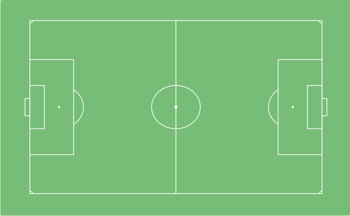

```r
library(ggplot2)
pitch()
```

### Lionel Messi vs Cristiano Ronaldo

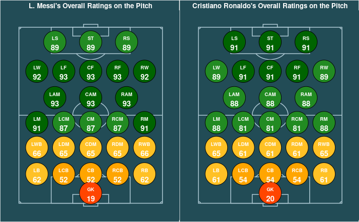

```r
library(gridExtra)
library(tibble)
library(dplyr)
library(magrittr)
library(cowplot)
library(sure)
plot_player_ratings <- function(data, player_name)({

    player <- data%>%filter(Name == player_name)%>%select(Position, LS:GK)
    # Transform from column to observation
    player <- suppressWarnings(as.data.frame(t(player)) %>%
      rownames_to_column("Pos") %>%
      filter(Pos != "Position")%>%
      mutate(V1 = as.numeric(str_sub(V1, end = 2)),
             Pos = as.character(Pos)))

    # Create pitch & positions
    pos <- data.frame(
      Pos = as.character(c("GK","LB","LCB","CB", "RCB","RB",
                          "LWB", "LDM", "CDM", "RDM", "RWB",
                          "LM", "LCM", "CM", "RCM", "RM",
                          "LAM", "CAM", "RAM",
                          "LW","LF","CF","RF","RW",
                          "LS","ST","RS")),
      x = c(7, rep(20,5), rep(38, 5), rep(55, 5), rep(72, 3), rep(90,5), rep(110,3)),
      y = c(40,rep(c(10, 25, 40,55,70), 3), c(20, 40, 60),c(10, 25, 40, 55,70), c(20, 40, 60)))%>%suppressWarnings()%>%suppressMessages()

    # Join player data & pitch
    player <- left_join(player, pos, by = 'Pos')%>%suppressWarnings()%>%suppressMessages()

    # Remove an unnecessary observation
    player <- na.omit(player)%>%suppressWarnings()%>%suppressMessages()


    p <- pitch(pitch_theme = "blue")+coord_flip()+
        geom_point(player, mapping = aes(x,y, fill = if_else(V1 < 50, "orangered",
                                        if_else(V1 <60, "orange",
                                                if_else(V1 < 70, "goldenrod1",
                                                        if_else(V1 <80, "palegreen4",
                                                                if_else(V1 < 90, "forestgreen",
                                                                        if_else(V1 == 0,
                                                                                "orangered","darkgreen"))))))), shape = 21, size = 15, show.legend = FALSE)+
    geom_text(player, mapping = aes(x,y, label = Pos), vjust= -0.5, color = "white", size = 2.5, fontface = "bold")+
    geom_text(player, mapping = aes(x,y, label = V1), vjust = 1.5, fontface = "bold", color = "white")+
    scale_fill_identity()+
    labs(title = paste0(player_name,"'s Overall Ratings on the Pitch"))+
    theme(plot.title = element_text(hjust = 0.5,vjust = -1, size = 10, color = "white", face = "bold"))
    return(p)

})


options(repr.plot.width = 20, repr.plot.height = 16)
grid.arrange(
    ggdraw() +
      draw_plot(plot_player_ratings(df, "L. Messi")) +
      draw_image(df%>%filter(Name == "L. Messi")%>%pull(Player.Photo)%>%as.character, scale=0.15, y=0.3, x=-0.34)+
      draw_image(df%>%filter(Name == "L. Messi")%>%pull(Club.Logo)%>%as.character, scale=0.15, y=0.3, x=0.34),
    ggdraw() +
      draw_plot(plot_player_ratings(df, "Cristiano Ronaldo")) +
      draw_image(df%>%filter(Name == "Cristiano Ronaldo")%>%pull(Player.Photo)%>%as.character, scale=0.15, y=0.3, x=-0.34)+
      draw_image(df%>%filter(Name == "Cristiano Ronaldo")%>%pull(Club.Logo)%>%as.character, scale=0.15, y=0.3, x=0.34),
    ncol = 2
    )
```

```r
NA
```

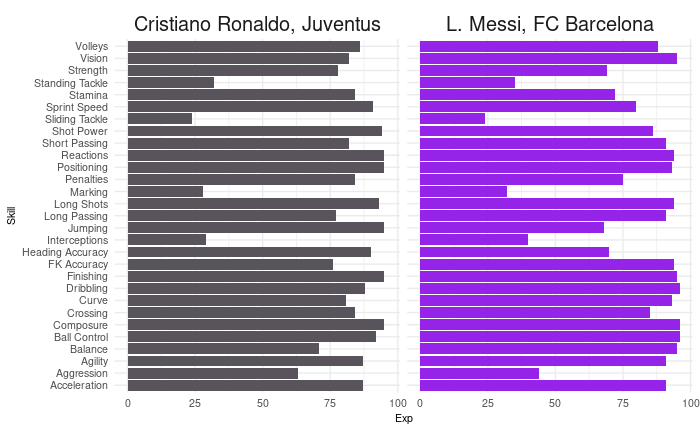

```r
players <- df2 %>%
  filter(Name %in% c("Cristiano Ronaldo", "L. Messi")) %>%
# Unite Name & Club variables
  mutate(Name = paste0(Name, ", ", Club)) %>%
# Selection abilities of the players
  select(Name,Crossing:Sliding.Tackle, -Mentality, -Power, -Defending, -Skill, -Movement ) %>%
# Correction of the punctuation
  rename_all(funs(gsub("[[:punct:]]", " ", .))) %>%
# Transform from Variable to Observation
  gather(Skill, Exp, Crossing:`Sliding Tackle`, -Name)


options(repr.plot.width = 15, repr.plot.height = 8)


ggplot(players, aes(Skill, Exp, fill = Name))+
  geom_col(show.legend = FALSE)+
  coord_flip()+
  facet_wrap(Name~.)+
  scale_fill_manual(values = c("#59545c", "#9623e8"))+
  theme_minimal()+
  theme(
      strip.text = element_text(size = 15),
      axis.title = element_text(size = 8),
      axis.text = element_text(size = 8)
  )
```

[figure not shown]

```r
options(repr.plot.width = 15, repr.plot.height = 8)


ggplot(players, aes(Skill, Exp, fill = Name))+
  geom_col(position = "fill")+
  coord_flip()+
  scale_fill_manual(values = c("#26241f", "#eda411"))+
  theme_minimal()+
  theme(
      strip.text = element_text(size = 20),
      axis.title = element_text(size = 13),
      axis.text = element_text(size = 8),
      legend.text = element_text(size = 16),
      plot.caption = element_text(size= 10)
  )+
  geom_hline(yintercept = 0.5, color = "white", size = 1, linetype = 2)+
  theme(legend.position = "top", axis.text.x=element_blank())+
  labs(caption = "@EA Sports - FIFA 21",
       fill = NULL,x = NULL, y = NULL)
```